# Week 7: Estimation, Part 2

PS 812 - Introduction to Statistical Methods in Political Science

Anton Strezhnev

strezhnev@wisc.edu

University of Wisconsin-Madison

October 20, 2026

## Welcome back!

$$\newcommand{\Var}{\text{Var}}
\newcommand{\Cov}{\text{Cov}}
\newcommand{\Corr}{\text{Corr}}
\newcommand{\indep}{\mathrel{\perp\mkern-10mu\perp}}$$

## Where we’ve been

Adapted from Blackwell (2025), Ch. 2

## Where we’ve been

- Under **i.i.d random sampling** from the target population, we’ve established that…

$\mathbb{E}[\hat{\mu}] =$

$\displaystyle \mathbb{E}\left[\frac{1}{n}\sum_{i=1}^n Y_i\right]$

$\displaystyle \frac{1}{n}\sum_{i=1}^n \mathbb{E}[Y_i]$

$\displaystyle \frac{1}{n}\sum_{i=1}^n \mu$

$\displaystyle \mu$

linearity of expectations

**identical**: $\mathbb{E}[Y_i] = \mu$

unbiased

$\Var(\hat{\mu}) =$

$\displaystyle \Var\left(\frac{1}{n}\sum_{i=1}^n Y_i\right)$

$\displaystyle \frac{1}{n^2}\left[\sum_{i=1}^n \Var(Y_i) + \sum_{i=1}^n \sum_{j \neq i} \Cov(Y_i, Y_j)\right]$

$\displaystyle \frac{1}{n^2}\sum_{i=1}^n \Var(Y_i)$

$\displaystyle \frac{1}{n^2}\sum_{i=1}^n \sigma^2$

$\displaystyle \frac{\sigma^2}{n}$

constants out squared; variance of a sum

**independent**: $\Cov(Y_i, Y_j) = 0$

**identical**: $\Var(Y_i) = \sigma^2$

sampling variance

$\hat{\mu} \sim \; {\color{#c5050c}{?}}\left(\mu, \dfrac{\sigma^2}{n}\right)$

## Where we’ve been

$\hat{\mu} \sim \; {\color{#c5050c}{?}}\left(\mu, \dfrac{\sigma^2}{n}\right)$

## This week

- **Convergence in distribution**
  - As sample size $n$ becomes large, is the sampling distribution **well-approximated** by a known distribution?
  - When a **central limit theorem** applies, the sampling distribution **converges in distribution** to a normal!
- **Plug-in estimation**
  - What if we want to learn other things about the **population** distribution?
  - A population *variance*? A population *covariance*?
  - Like the mean, these are all **functionals** of the population CDF
  - Under i.i.d. sampling, plugging in the **sample** CDF usually gives a good estimator!
- **Density estimation**
  - Histograms and binning
  - **Kernel** estimators (weighted averages w/ weights determined by *closeness*)

## Big-$O$ and little-$o$ notation

- Sometimes we’ll want to use **shorthand** to characterize how fast a term **shrinks** (or grows)
- Little-$o$ notation: $a_n = o(b_n)$ means $\dfrac{a_n}{b_n} \to 0$ as $n \to \infty$
  - $a_n$ vanishes **faster** than $b_n$, e.g. $\frac{1}{n^2} = o\left(\frac{1}{n}\right)$
- Big-$O$ notation: $a_n = O(b_n)$ means $\left|\dfrac{a_n}{b_n}\right|$ stays **bounded** as $n \to \infty$
  - $a_n$ vanishes **no slower** than $b_n$, e.g. $\Var(\bar{Y}_n) = \frac{\sigma^2}{n} = O\left(\frac{1}{n}\right)$
- So $o(1)$ is anything going to $0$, and $O(1)$ is anything that stays bounded

## Big-$O_p$ and little-$o_p$ notation

- For **random variables**, the same shorthand is stated in terms of **probabilities**
- Little-$o_p$ notation denotes convergence (in probability) to **zero**
  - $Y_n = o_p(1)$ means $\Pr(|Y_n| \ge \epsilon) \to 0$ as $n \to \infty$, for every $\epsilon > 0$
  - e.g. by the WLLN, we can write $\bar{Y}_n = \mu + o_p(1)$
- Big-$O_p$ notation denotes **boundedness** (in probability) of a sequence as $n \to \infty$
  - $Y_n = O_p(1)$ means that for every $\epsilon > 0$ there’s an $M$ with $\Pr(|Y_n| > M) < \epsilon$ for all sufficiently large $n$
- The rest of the orders are defined by **rescaling**
  - So $Y_n = O_p(a_n)$ means that $\frac{Y_n}{a_n} = O_p(1)$, and likewise for $o_p$

## Big-$O_p$ and little-$o_p$ notation

- Useful properties
  - $o_p(1) + o_p(1) = o_p(1)$
  - $o_p(1) + O_p(1) = O_p(1)$
  - $O_p(1)o_p(1) = o_p(1)$
  - If a sequence is $o_p(1)$, it is $O_p(1)$ but not vice-versa
- Most common use: **convergence rates**.
  - **How quickly** does $\bar{Y}_n$ converges to $\mu$?
  - It turns out $\bar{Y}_n - \mu = O_p(1/\sqrt{n})$: the error shrinks at rate $1/\sqrt{n}$

## Convergence in distribution

- By the Weak Law of Large Numbers (WLLN) $\bar{Y}_n \xrightarrow{p} \mu$
  - Tells us how the sampling distribution **collapses** to the point we want…
  - …but says nothing about the **shape** of the sampling distribution for any given $n$
- To approximate the sampling distribution in a large (but finite) sample, we need a notion of convergence to a **random variable**
  - Does the *distribution* of $bar{Y}_n$ get close to some known *distribution* as $n$ gets large?
- **Convergence in distribution**
  - A sequence of random variables $X_n$ with CDFs $F_n$ **converges in distribution** to a random variable $X$ with CDF $F$ if
    $$\lim_{n \to \infty} F_n(x) = F(x)$$
    at every $x$ where $F$ is continuous
- We’ll denote this as $X_n \xrightarrow{d} X$.

## Convergence in distribution

- We want to approximate the sampling distribution of $\bar{Y}_n$. Does $\bar{Y}_n$ itself converge in distribution?
  - Convergence in *probability* implies convergence in *distribution*
  - So we end up with a useless result: $\bar{Y}_n \xrightarrow{p} \mu$, so $\bar{Y}_n \xrightarrow{d} \mu$
  - And recentering still gives $\bar{Y}_n - \mu \xrightarrow{d} 0$
- We need to analyze a sequence that does not **collapse** to a single point
- We’ll **rescale** $\bar{Y}_n - \mu$ by some factor that guarantees the variance converges to a non-zero **constant**
  $$\Var\big(n^r(\bar{Y}_n - \mu)\big) = n^{2r} \cdot \frac{\sigma^2}{n} = \sigma^2 n^{2r - 1} \to \begin{cases} 0 & r < 1/2 \\ \sigma^2 & r = 1/2 \\ \infty & r > 1/2 \end{cases}$$
- So scaling the error by $\sqrt{n}$ keeps the variance **stable**:
  - This is what we’ll analyze: $\sqrt{n}(\bar{Y}_n - \mu)$
  - Its mean ($0$) and variance ($\sigma^2$) never change with $n$. What about its **shape**?

## The Central Limit Theorem

**Sums** and **means** of independent and identically distributed random variables tend to be **normally distributed**.

## The Central Limit Theorem

- **Central Limit Theorem**: Let $Y_1, Y_2, \dotsc, Y_n$ be i.i.d. with $\mathbb{E}[Y_i] = \mu$ and $\Var(Y_i) = \sigma^2 < \infty$. Then
  $$\sqrt{n}(\bar{Y}_n - \mu) \xrightarrow{d} \mathcal{N}(0, \sigma^2)$$
- Equivalently, the **standardized** sample mean $\dfrac{\bar{Y}_n - \mu}{\sigma/\sqrt{n}} \xrightarrow{d} \mathcal{N}(0, 1)$
- In the limit, the only things that matter about $Y_i$ after averaging are its **mean** and **variance**
  - Whatever the shape of $Y_i$, the averages become (roughly) normal.
- We’ll use this to say that for large $n$, the sample mean is **approximately** normal
  $$\bar{Y}_n \overset{a}{\sim} \mathcal{N}\left(\mu, \frac{\sigma^2}{n}\right)$$
- Let’s prove it!

## Moment generating functions

- Our proof requires a new concept: a **moment generating function**
  - This is a useful mathematical trick which lets us analyze an entire distribution by studying just **one** function.
  - Then we can apply the tools of calculus - specifically **Taylor approximations** and limits of functions
- The **moment generating function** (MGF) of a random variable $X$ is
  $$M_X(t) = \mathbb{E}\left[e^{tX}\right]$$
  so long as it’s finite for all $t$ in some interval around $0$
- Taking the derivative and evaluating at $t = 0$ generates the **moments**:
  - $M_X(0) = 1$
  - $M_X'(0) = \mathbb{E}[X]$
  - $M_X''(0) = \mathbb{E}[X^2]$, …

## Moment generating functions

- Properties that we need:
  1. **Uniqueness**: Two random variables with the same MGF have the same distribution
  2. **Continuity**: If $M_{X_n}(t) \to M_X(t)$ for every $t$ near $0$, then $X_n \xrightarrow{d} X$
  3. **Independent sums**: If $X_1 \indep X_2$, then $M_{X_1 + X_2}(t) = \mathbb{E}\left[e^{tX_1}e^{tX_2}\right] = M_{X_1}(t)M_{X_2}(t)$
  4. **The MGF of the Normal**: If $X \sim \mathcal{N}(0, \sigma^2)$, then $M_X(t) = e^{\sigma^2 t^2/2}$
- **Our goal**: Show that the MGF of $\sqrt{n}(\bar{Y}_n - \mu)$ converges to $e^{\sigma^2 t^2/2}$

## Proving the Central Limit Theorem

- Define $W_i = Y_i - \mu$, the **centered** draw, and let $M(t) = \mathbb{E}\left[e^{tW_i}\right]$ be its MGF. Then
  $$M(0) = 1, \qquad M'(0) = \mathbb{E}[W_i] = 0, \qquad M''(0) = \mathbb{E}[W_i^2] = \sigma^2$$
- Writing the scaled **sum** of the $W_i$
  $$\sqrt{n}(\bar{Y}_n - \mu) = \frac{1}{\sqrt{n}}\sum_{i=1}^n W_i$$
- Call the MGF of this scaled error $M_n(t)$. We first want to write $M_n(t)$ in terms of $M(t)$
- We’ll assume the MGF $M$ exists
  - The general proof uses the *characteristic function* $\mathbb{E}[e^{itW_i}]$, which always exists.

## Proving the Central Limit Theorem

- First, turn the **sum** in the exponent into a **product**
  $$\begin{aligned}
  M_n(t) &= \mathbb{E}\left[e^{t\sqrt{n}(\bar{Y}_n - \mu)}\right] && \small\color{#777777}{\text{definition of the MGF}} \\
  &= \mathbb{E}\left[\exp\left(\tfrac{t}{\sqrt{n}}\textstyle\sum_{i=1}^n W_i\right)\right] && \small\color{#777777}{\text{scaled error = scaled sum}} \\
  &= \mathbb{E}\left[\exp\left(\textstyle\sum_{i=1}^n \tfrac{t}{\sqrt{n}} W_i\right)\right] && \small\color{#777777}{\text{constant inside the sum}} \\
  &= \mathbb{E}\left[\textstyle\prod_{i=1}^n \exp\left(\tfrac{t}{\sqrt{n}} W_i\right)\right] && \small\color{#777777}{e^{a + b} = e^a e^b}
  \end{aligned}$$
- Then use the **i.i.d.** properties
  $$\begin{aligned}
  \mathbb{E}\left[\textstyle\prod_{i=1}^n \exp\left(\tfrac{t}{\sqrt{n}} W_i\right)\right] &= \textstyle\prod_{i=1}^n \mathbb{E}\left[\exp\left(\tfrac{t}{\sqrt{n}} W_i\right)\right] && \small\color{#777777}{\text{independent}} \\
  &= \textstyle\prod_{i=1}^n M\left(\tfrac{t}{\sqrt{n}}\right) && \small\color{#777777}{\text{identical: each $W_i$ has MGF $M$}} \\
  &= \left[M\left(\tfrac{t}{\sqrt{n}}\right)\right]^n && \small\color{#777777}{\text{$n$ identical factors}}
  \end{aligned}$$

## Proving the Central Limit Theorem

- Take a second-order Taylor expansion of $M(t)$ around $t = 0$
  $$M(t) = M(0) + t\,M'(0) + \frac{t^2}{2}M''(0) + o(t^2) = 1 + 0 + \frac{\sigma^2 t^2}{2} + o(t^2)$$
  $o(t^2)$ is the remainder - we use little-o notation to show that it goes to $0$ **faster** than $t^2$
- Evaluate it at $t/\sqrt{n}$, which goes to $0$ as $n$ grows
  $$M_n(t) = \left[M\left(\frac{t}{\sqrt{n}}\right)\right]^n = \left[1 + \frac{\sigma^2 t^2}{2n} + o\left(\frac{1}{n}\right)\right]^n$$
- Factor so this looks like the familiar **compound interest** formula.
  $$M_n(t) = \left(1 + \frac{a_n}{n}\right)^n, \qquad a_n = \frac{\sigma^2 t^2}{2} + n \cdot o\left(\frac{1}{n}\right)$$
- The remainder is $o\left(\frac{1}{n}\right)$ and shrinks **faster** than $\frac{1}{n}$, so even $n$ times it goes to $0$.
  - So $a_n \to a = \frac{\sigma^2 t^2}{2}$

## Proving the Central Limit Theorem

- Since $a_n \to a$, for large $n$ our $M_n(t)$ behaves just like compound interest at the fixed rate $a$, which is one our definitions of $e$.
  $$M_n(t) = \left(1 + \frac{a_n}{n}\right)^n \approx \left(1 + \frac{a}{n}\right)^n \to e^{a} = e^{\sigma^2 t^2/2}$$
- That’s the MGF of a $\mathcal{N}(0, \sigma^2)$, so $\sqrt{n}(\bar{Y}_n - \mu) \xrightarrow{d} \mathcal{N}(0, \sigma^2)$

For an alternative proof that takes logs and applies L’Hôpital’s rule, see Blitzstein and Hwang (2019), Ch. 10

## Many central limit theorems

- What we proved is the **Lindeberg–Lévy** CLT. There are many other CLTs, each under different data-generating processes

| CLT | Relaxes | Needs | Where you’ll see it |
| --- | --- | --- | --- |
| **Lindeberg–Lévy** |  | i.i.d., finite variance | Sample means under random sampling |
| **Lindeberg–Feller**, **Lyapunov** | Identical distribution | No single term dominates the total variance | Heteroskedastic errors, robust SEs |
| **Clustered** | Independence within clusters | Many independent clusters, none dominant | Clustered samples, cluster-robust SEs |
| **Mixing**, **$m$-dependent** | Independence across time or space | Dependence dies out with distance | Time series and spatial data, HAC SEs |
| **Martingale** | Independence | Each term has mean zero given the past | Time series, adaptive experiments |
| **Finite-population** (Hájek) | An infinite population | $n$ and $N - n$ both large | Survey sampling, randomization inference |
| **Multivariate** | A single mean | Finite covariance matrix | Regression coefficients |

- The theme: a sum of many **small**, **not-too-dependent** pieces is approximately normal.
  - What changes is the **sampling variance**

## Properties of convergence in distribution

- Consider $X_n \xrightarrow{d} X$, $Y_n \xrightarrow{p} c$ for a **constant** $c$, and a continuous function $g()$
- By the continuous mapping theorem, $g(X_n) \xrightarrow{d} g(X)$
- By **Slutsky’s theorem**
1. $X_n + Y_n \xrightarrow{d} X + c$
2. $X_nY_n \xrightarrow{d} cX$
3. $X_n/Y_n \xrightarrow{d} X/c$ if $c \neq 0$
- Careful: $X_n \xrightarrow{d} X$ and $Y_n \xrightarrow{d} Y$ does **not** imply $X_n + Y_n \xrightarrow{d} X + Y$ in general
- Why this matters: we don’t know $\sigma$, but if $\hat{\sigma} \xrightarrow{p} \sigma$ (more on this later), we can plug it in and still know the asymptotic distribution.
  $$\frac{\bar{Y}_n - \mu}{\hat{\sigma}/\sqrt{n}} = \underbrace{\frac{1}{\hat{\sigma}}}_{\xrightarrow{p} 1/\sigma} \cdot \underbrace{\sqrt{n}(\bar{Y}_n - \mu)}_{\xrightarrow{d} \mathcal{N}(0, \sigma^2)} \xrightarrow{d} \frac{1}{\sigma}\mathcal{N}(0, \sigma^2) = \mathcal{N}(0, 1)$$

## What we’ve accomplished

$\hat{\mu} \overset{a}{\sim} \; {\color{#c5050c}{\mathcal{N}}}\left(\mu, \dfrac{\sigma^2}{n}\right)$

- Under i.i.d. sampling with a finite variance, the CLT fills in the question mark: in large samples, the sampling distribution of the sample mean is approximately **normal**
- How large is “large”? It depends on the distribution of $Y_i$.

## Plug-in estimators

- So far, we’ve estimated one feature of the population: the mean $\mu = \mathbb{E}[Y_i]$, with the sample mean $\bar{Y}_n$
- But we often want to learn **other** features of the population distribution
  - The variance $\sigma^2$ (which we need for standard errors)
  - The median, or some other quantile
  - The share of the population above some threshold, $\Pr(Y_i > c)$
- **Informally**: Write down the feature of the **population** we care about, then compute its **sample analog**
  - Expected value $\rightarrow$ sample mean.
  - Variance $\rightarrow$ sample variance.
- Each of these features is a **function of the CDF** $F$
  - Estimate $F$ with its sample analog, then **plug it in**

## The empirical CDF

- By the **fundamental bridge**, the CDF is an expectation of an indicator random variable

  $$F(y) = \Pr(Y_i \le y) = \mathbb{E}\left[I(Y_i \le y)\right]$$
- Its sample analog is the **empirical CDF**: replace the expectation with a sample mean
  $$\hat{F}_n(y) = \frac{1}{n}\sum_{i=1}^n I(Y_i \le y) = \text{share of observations at or below } y$$
- A **step function** that jumps by $\frac{1}{n}$ at each observation, even when $Y_i$ is continuous

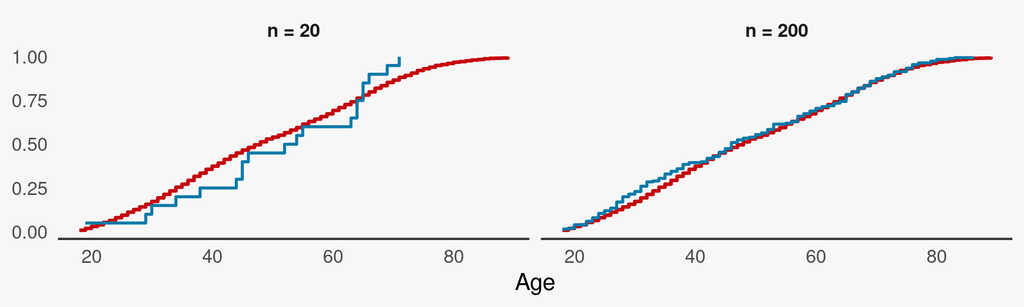

## The empirical CDF

- For any given value of $y$, the indicators $Z_i = I(Y_i \le y)$ are i.i.d. Bernoulli with mean $\Pr(Y_i \le y) = F(y)$
- So $\hat{F}_n(y) = \bar{Z}_n$ is just a **sample mean**, and everything we know about sample means applies
  - Unbiased: $\mathbb{E}\left[\hat{F}_n(y)\right] = F(y)$
  - Sampling variance: $\Var\left(\hat{F}_n(y)\right) = \dfrac{F(y)\big(1 - F(y)\big)}{n}$
  - Consistent (WLLN): $\hat{F}_n(y) \xrightarrow{p} F(y)$
  - Asymptotically normal (CLT): $\sqrt{n}\left(\hat{F}_n(y) - F(y)\right) \xrightarrow{d} \mathcal{N}\big(0, F(y)(1 - F(y))\big)$
- Even stronger, the **Glivenko–Cantelli theorem** shows that the **largest** gap over all $y$ also goes to zero (with probability 1)
  $$\sup_y \left|\hat{F}_n(y) - F(y)\right| \to 0$$
  - The whole curve converges

## The plug-in principle

- A **statistical functional** $T$ maps a CDF to a number. Many estimands can be written as $\theta = T(F)$
- Notation: $\int g(y)\,dF(y)$ means $\sum_y g(y) f(y)$ if $Y_i$ is discrete, or $\int g(y) f(y)\,dy$ if it’s continuous.
  - It’s $\mathbb{E}[g(Y_i)]$
- Examples
  - Mean: $\mu = T_{\mu}(F) = \int y\,dF(y)$
  - Variance: $\sigma^2 = T_{\sigma^2}(F) = \int y^2\,dF(y) - \left(\int y\,dF(y)\right)^2$
  - Median: $T_{\text{med}}(F) = F^{-1}(1/2)$
  - Tail probability: $\Pr(Y_i > c) = 1 - F(c)$
- The **plug-in estimator** of $\theta = T(F)$ applies the same functional to the empirical CDF
  $$\hat{\theta} = T(\hat{F}_n)$$

## The plug-in principle

- $\hat{F}_n$ is the CDF of a discrete distribution that puts mass $\frac{1}{n}$ on each observation, so for any $g$
  $$\int g(y)\,d\hat{F}_n(y) = \sum_{i=1}^n g(Y_i) \cdot \frac{1}{n} = \frac{1}{n}\sum_{i=1}^n g(Y_i)$$
  - Every **expectation** becomes a **sample mean**
- Mean: $T_{\mu}(\hat{F}_n) = \frac{1}{n}\sum_{i=1}^n Y_i = \bar{Y}_n$.
- Variance: $T_{\sigma^2}(\hat{F}_n) = \frac{1}{n}\sum_{i=1}^n Y_i^2 - \bar{Y}_n^2 = \frac{1}{n}\sum_{i=1}^n (Y_i - \bar{Y}_n)^2$, the **plug-in sample variance**
- Median: $\hat{F}_n^{-1}(1/2)$, the sample median.
- Tail probability: $1 - \hat{F}_n(c)$, the share of observations above $c$

## Bias of the plug-in variance

- The population variance
  $$\sigma^2 = \mathbb{E}[Y_i^2] - \mu^2$$
- We can re-write our plug-in variance estimator the same way.

  $$\begin{aligned}
  \hat{\sigma}^2_n &= \frac{1}{n}\sum_{i=1}^n (Y_i - \bar{Y}_n)^2 \\
  &= \frac{1}{n}\sum_{i=1}^n \left(Y_i^2 - 2Y_i\bar{Y}_n + \bar{Y}_n^2\right) && \small\color{#777777}{\text{expand the square}} \\
  &= \frac{1}{n}\sum_{i=1}^n Y_i^2 - 2\bar{Y}_n \cdot \frac{1}{n}\sum_{i=1}^n Y_i + \frac{1}{n}\sum_{i=1}^n \bar{Y}_n^2 && \small\color{#777777}{\text{split the sum; } \bar{Y}_n \text{ doesn't depend on } i} \\
  &= \frac{1}{n}\sum_{i=1}^n Y_i^2 - 2\bar{Y}_n \cdot \bar{Y}_n + \bar{Y}_n^2 && \small\color{#777777}{\tfrac{1}{n}\textstyle\sum_i Y_i = \bar{Y}_n \text{, and } n \text{ copies of } \bar{Y}_n^2} \\
  &= \frac{1}{n}\sum_{i=1}^n Y_i^2 - \bar{Y}_n^2
  \end{aligned}$$

## Bias of the plug-in variance

- Is it **unbiased**? Take the expectation of each piece. First, the average of the squares
  $$\begin{aligned}
  \mathbb{E}\left[\frac{1}{n}\sum_{i=1}^n Y_i^2\right] &= \frac{1}{n}\sum_{i=1}^n \mathbb{E}\left[Y_i^2\right] && \small\color{#777777}{\text{linearity of expectations}} \\
  &= \frac{1}{n} \cdot n\,\mathbb{E}\left[Y_i^2\right] = \mathbb{E}\left[Y_i^2\right] && \small\color{#777777}{\text{identically distributed}}
  \end{aligned}$$
- Then the square of the average. Rearrange $\Var(X) = \mathbb{E}[X^2] - \mathbb{E}[X]^2$ with $X = \bar{Y}_n$
  $$\begin{aligned}
  \mathbb{E}\left[\bar{Y}_n^2\right] &= \Var(\bar{Y}_n) + \mathbb{E}[\bar{Y}_n]^2 \\
  &= \frac{\sigma^2}{n} + \mu^2 && \small\color{#777777}{\text{last week: } \mathbb{E}[\bar{Y}_n] = \mu,\ \Var(\bar{Y}_n) = \sigma^2/n}
  \end{aligned}$$
  - $\mathbb{E}[\bar{Y}_n^2] \neq \mathbb{E}[\bar{Y}_n]^2$: the sample mean’s own sampling variance appears!

## Bias of the plug-in variance

- Combining the components
  $$\begin{aligned}
  \mathbb{E}\left[\hat{\sigma}^2_n\right] &= \mathbb{E}\left[\frac{1}{n}\sum_{i=1}^n Y_i^2\right] - \mathbb{E}\left[\bar{Y}_n^2\right] && \small\color{#777777}{\text{linearity of expectations}} \\
  &= \mathbb{E}\left[Y_i^2\right] - \left(\frac{\sigma^2}{n} + \mu^2\right) && \small\color{#777777}{\text{the two pieces}} \\
  &= \left(\mathbb{E}\left[Y_i^2\right] - \mu^2\right) - \frac{\sigma^2}{n} && \small\color{#777777}{\text{regroup}} \\
  &= \sigma^2 - \frac{\sigma^2}{n} && \small\color{#777777}{\text{definition of } \sigma^2} \\
  &= \frac{n - 1}{n}\sigma^2
  \end{aligned}$$
- So it’s **biased** downward: on average, it’s too small by $\frac{\sigma^2}{n}$
  - Intuition: Think about computing the plug-in variance with just a **single** observation!

## Fixing the bias

- How big is the bias? $\mathbb{E}\left[\hat{\sigma}^2_n\right] = \frac{n-1}{n}\sigma^2$ is too small by a fraction $\frac{1}{n}$
- Rescale by $\frac{n}{n-1}$ to get the **unbiased sample variance estimator** (R’s `var()`)
  $$S^2_n = \frac{n}{n-1}\hat{\sigma}^2_n = \frac{1}{n-1}\sum_{i=1}^n (Y_i - \bar{Y}_n)^2 \qquad \mathbb{E}\left[S^2_n\right] = \frac{n}{n-1} \cdot \frac{n-1}{n}\sigma^2 = \sigma^2$$
- Dividing by $n - 1$ instead of $n$ eliminates the bias (“Bessel’s correction”)
- But the bias **vanishes** as $n$ grows. Does $\hat{\sigma}^2_n$ still get the right answer in large samples?

## Consistency of the plug-in variance

- The $Y_i^2$ are i.i.d. with mean $\mathbb{E}[Y_i^2]$, so by the WLLN
  $$\frac{1}{n}\sum_{i=1}^n Y_i^2 \xrightarrow{p} \mathbb{E}[Y_i^2]$$
- By the WLLN, $\bar{Y}_n \xrightarrow{p} \mu$. A limit of a product is the product of the limits, so $\bar{Y}_n^2 = \bar{Y}_n \cdot \bar{Y}_n \xrightarrow{p} \mu^2$
- A sum (or difference) converges to the sum of the limits, so
  $$\hat{\sigma}^2_n = \frac{1}{n}\sum_{i=1}^n Y_i^2 - \bar{Y}_n^2 \xrightarrow{p} \mathbb{E}[Y_i^2] - \mu^2 = \sigma^2$$
- Biased, but **consistent**

## Consistency of plug-in estimators

- In general: $\hat{F}_n \to F$. So if small changes in $F$ only cause small changes in $T(F)$, then $T(\hat{F}_n) \to T(F)$
  - In other words, $T$ needs to be **continuous** (in a particular sense)
- Under some additional regularity conditions, plug-in estimators are also **asymptotically normal**
  - This involves a kind of differentiability of $T$ with respect to the **distribution** $F$.
- Most estimands we’ll work with are well behaved: means, variances, covariances, quantiles (where $F$ isn’t flat), regression coefficients
- When does it fail? When $T$ is too **sensitive** to small changes in $F$
  - The **density** $f(y) = F'(y)$: $\hat{F}_n$ is a step function and fails **continuity**
  - Plugging $\hat{F}_n$ straight doesn’t work. We’ll need to **smooth** it.

## Running Example: 2024 GSS

- Estimate features of the **age** distribution of U.S. adults from the 3,859 GSS respondents, treating them as an i.i.d. sample

| Estimand $\theta = T(F)$ | Plug-in estimator $T(\hat{F}_n)$ | Estimate |
| --- | --- | --- |
| Mean age, $\mathbb{E}[Y_i]$ | $\bar{Y}_n$ | 49.0 |
| Variance, $\Var(Y_i)$ | $\frac{1}{n}\sum_{i=1}^n (Y_i - \bar{Y}_n)^2$ | 311.9 |
| Median, $F^{-1}(1/2)$ | Sample median | 48 |
| Share 65 or older, $\Pr(Y_i \ge 65)$ | $1 - \hat{F}_n(64)$ | 0.236 |

- With $n$ this large, the $\frac{n}{n-1}$ correction barely matters: $S^2_n = 312.0$
- And the standard error of the mean: $\widehat{SE}(\bar{Y}_n) = S_n / \sqrt{n} = 0.284$

## Running Example in R

```r
library(tidyverse)

gss <- read_csv("../week6/data/gss2024.csv") |>
  filter(!is.na(age))       # the GSS top-codes age at 89

Fhat <- ecdf(gss$age)       # the empirical CDF, as an R function

age_est <- gss |>
  summarize(n = n(),
            mean = mean(age),
            var_plugin = mean((age - mean(age))^2),
            var_unbiased = var(age),
            median = median(age),
            share65 = 1 - Fhat(64))
age_est
```

```
# A tibble: 1 × 6
      n  mean var_plugin var_unbiased median share65
  <int> <dbl>      <dbl>        <dbl>  <dbl>   <dbl>
1  3859  49.0       312.         312.     48   0.236
```

## Density estimation

- The plug-in principle can’t give us the **density** $f(y)$ directly
  - But the density is often the best way to visualize the shape of a distribution
- Recall what a **density** is: the share of the population in a small window around $y$, divided by the window’s width
  $$f(y) \approx \frac{F(y + h/2) - F(y - h/2)}{h} \qquad \text{for small } h$$
- Plug in $\hat{F}_n$: the share of the **sample** within $h/2$ of $y$, divided by $h$
  $$\hat{f}(y) = \frac{\hat{F}_n(y + h/2) - \hat{F}_n(y - h/2)}{h} = \frac{\#\{i : |Y_i - y| \le h/2\}}{nh}$$
- The width $h$ is a **tuning parameter**
  - Too small and each window holds few observations (**noisy**)
  - Too large and we average over a region where $f$ changes (**biased**)

## Histograms

- A **histogram** splits the real number line into **bins** $B_1, B_2, \dotsc$ of width $h$. For $y$ in bin $B_j$
  $$\hat{f}(y) = \frac{\#\{i : Y_i \in B_j\}}{nh}$$
  - Each bar’s **area** is the share of observations in its bin, so the areas sum to $1$
- **Bias**: the bar is flat but $f$ might not be. Larger $h$ $\leadsto$ larger bias (depending on $f^\prime(y)$)
- **Variance**: the count in a bin is binomial with $n$ trials and success probability approximately $hf(y)$
  $$\Var\left(\hat{f}(y)\right) \approx \frac{n hf(y) (1 - hf(y))}{(nh)^2} = \frac{f(y)}{nh} (1 - hf(y)) \approx \frac{f(y)}{nh} \qquad \text{for small } h$$
- Consistent if the bins shrink, $h \to 0$, but **slowly** enough that each still fills up, $nh \to \infty$

See Wasserman (2006), Ch. 6

## Choosing the bin width

- Pick $h$ to minimize the **integrated mean squared error** across all $y$. For small $h$ (Scott 1979)
  $$\text{IMSE}(h) \approx \underbrace{\frac{h^2}{12}\int f'(y)^2\,dy}_{\text{bias}^2} + \underbrace{\frac{1}{nh}}_{\text{variance}} \quad \Longrightarrow \quad h^* = \left(\frac{6}{\int f'(y)^2\,dy}\right)^{1/3} n^{-1/3}$$
  - Bins shrink at a rate of $n^{-1/3}$, so the **number** of bins grows like $n^{1/3}$
- $h^*$ depends on the unknown $f$ through $\int f'(y)^2\,dy$. Heuristics plug in a **reference** distribution
  - **Scott** (normal reference distribution): $h = 3.49\,\hat{\sigma}\,n^{-1/3}$ (Scott 1979)
  - **Freedman–Diaconis**: $h = 2\,\text{IQR}\,n^{-1/3}$ (Freedman and Diaconis 1981)
  - **Sturges**: $\lceil \log_2 n \rceil + 1$ bins (Sturges 1926). This is R’s default in `hist()` - tends to use too few bins in large samples

## How many bins?

[figure not shown]

- Too narrow: mostly **noise**. Too wide: the shape gets **smoothed away**

## Kernel density estimation

- A histogram’s estimate at $y$ depends on where the bin **edges** happen to fall
- Instead, we could imagine centering a window on **every** point $y$ (Rosenblatt 1956)
  $$\hat{f}(y) = \frac{1}{nh}\sum_{i=1}^n I\left(|Y_i - y| \le \tfrac{h}{2}\right)$$
- A **weighted count**: observations within $h/2$ of $y$ get weight $1$. Everyone else gets **nothing**
  - But instead of weighting every observation in the window equally, we could let an observation’s weight **fall off smoothly** with its distance from $y$

## Kernel density estimation

- The **kernel density estimator** (Rosenblatt 1956; Parzen 1962)

  $$\hat{f}_h(y) = \frac{1}{nh}\sum_{i=1}^n K_h(Y_i - y)$$
- Where the **kernel** is defined as:

  $$K_h(u) = K\left(\frac{u}{h}\right)$$
- The **kernel** $K$ is a function that is symmetric, non-negative and integrates to $1$:
  - e.g. uniform, triangular $1 - |u|$ on $[-1, 1]$, Gaussian $\phi(u)$
  - The choice of kernel defines the shape of how the weights decay from $y$
- The **bandwidth** $h$ defines how *many* observations get meaningful weight.

## Kernel density estimation

- Each observation contributes a small **bump** $\frac{1}{nh}K_h(\cdot - Y_i)$ (dashed). The estimate is their **sum** (solid)

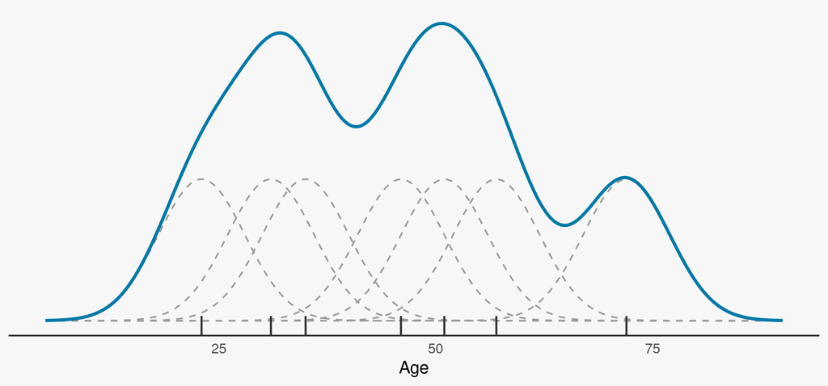

## Kernel density estimation

- Same observations with a **triangular** kernel instead of a **gaussian**/**normal** kernel

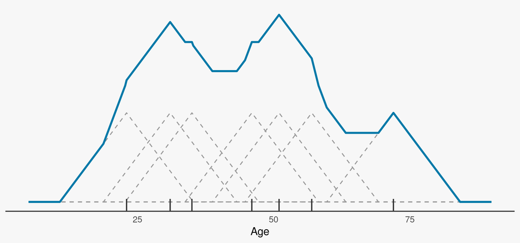

## Running Example: 2024 GSS

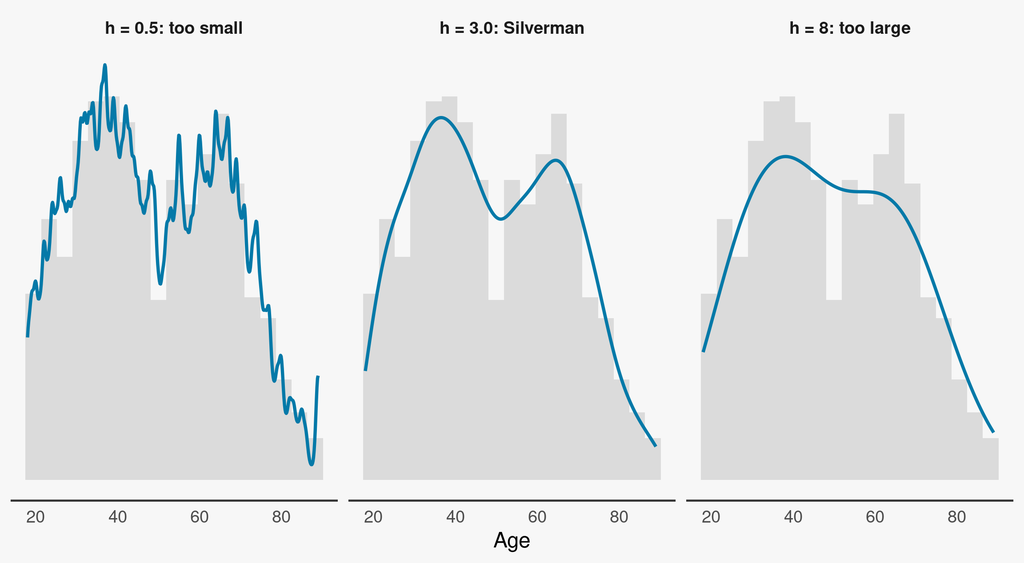

## Running Example in R

```r
h_fd   <- 2 * IQR(gss$age) / nrow(gss)^(1/3)   # Freedman-Diaconis bin width
bw_rot <- bw.nrd0(gss$age)                     # Silverman's rule of thumb
c(bin_width = h_fd, bandwidth = bw_rot)
```

```
bin_width bandwidth
 3.825249  3.047998
```

```r
fhat <- density(gss$age, bw = bw_rot)          # Gaussian kernel by default
approx(fhat$x, fhat$y, xout = c(30, 60))$y     # estimated density at ages 30 and 60
```

```
[1] 0.01749374 0.01663595
```

```r
ggplot(gss, aes(age)) +
  geom_histogram(aes(y = after_stat(density)), binwidth = h_fd) +
  geom_density(bw = bw_rot)
```

## Next week

- What do we do now that we have the **sampling distribution** of the sample mean?
- **Interval estimators**
  - Instead of a **single point estimate** can we give a range of values that characterizes our uncertainty?
  - **Confidence interval**: In some fraction (e.g. 95%) of samples, the bounds will cover the true parameter.
  - For a consistent and asymptotically normal estimator, this is just $\hat{\mu} \pm 1.96 \times \widehat{SE(\hat{\mu})}$ (for a 95% CI).
- **Hypothesis testing**
  - A thought experiment: If the true population mean were $\mu_0$, how likely would I be to observe a realization **as extreme** as the one in my sample?
  - This is a **p-value**
  - If the value is sufficiently unlikely…I may be willing to believe that the true population mean **is not** $\mu_0$

## References

Blackwell, Matthew. 2025. *A User’s Guide to Statistical Inference and Regression*. https://mattblackwell.github.io/gov2002-book/.

Blitzstein, Joseph K., and Jessica Hwang. 2019. *Introduction to Probability*. 2nd ed. Boca Raton, FL: Chapman; Hall/CRC. https://projects.iq.harvard.edu/stat110/home.

Freedman, David, and Persi Diaconis. 1981. “On the Histogram as a Density Estimator: $L_2$ Theory.” *Zeitschrift für Wahrscheinlichkeitstheorie Und Verwandte Gebiete* 57 (4): 453–76. https://doi.org/10.1007/BF01025868.

Parzen, Emanuel. 1962. “On Estimation of a Probability Density Function and Mode.” *The Annals of Mathematical Statistics* 33 (3): 1065–76. https://doi.org/10.1214/aoms/1177704472.

Rosenblatt, Murray. 1956. “Remarks on Some Nonparametric Estimates of a Density Function.” *The Annals of Mathematical Statistics* 27 (3): 832–37. https://doi.org/10.1214/aoms/1177728190.

Scott, David W. 1979. “On Optimal and Data-Based Histograms.” *Biometrika* 66 (3): 605–10. https://doi.org/10.1093/biomet/66.3.605.

Sturges, Herbert A. 1926. “The Choice of a Class Interval.” *Journal of the American Statistical Association* 21 (153): 65–66. https://doi.org/10.1080/01621459.1926.10502161.

Wasserman, Larry. 2006. *All of Nonparametric Statistics*. New York: Springer. https://doi.org/10.1007/0-387-30623-4.